# SQL CHALLENGE: Team Result Analytics

This is a Dashboard Query Questions Nowadays asked in Top Product Based Companies originally shared by @Gurgesh Yadav on LinkedIn. Please follow him for more SQL contents.

Uber, Target, Amazon, and Microsoft - This Dashboarding Type of SQL Medium interview questions are asked by these companies.

I used SQL workbench to solve this challenge.

### Question:

Write a query to get the following transition: (Here I/P = Input Table, O/P = Output Table)

### I/P

| Team1 |  | Team2 |  | Result |
| --- | --- | --- | --- | --- |
| A |  | B |  | A |
| A |  | C |  | C |
| B |  | D |  | D |
| A |  | D |  | A |

### O/P

[output not shown]

### Solution:

1. Create the Input Table with the code below:

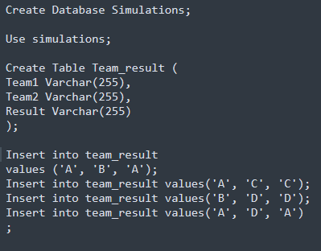

[figure not shown]

The following are some important ideas to consider while you analyze the output:

- It took me almost 6 hours to find the solution.
- Team1 against Result and Team2 against Result were the 2 columns I unpicked.
- Afterwards, I combined the seperate queries to produce 2 columns: Team and Result using UNION ALL. Unpivot can also be used. However, I'm using MySQL Workbench in this instance.

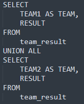

- I used cte instead of a subquery to make the work more readable.

Can subquery be used to achieve this? In a word, yes

- I manipulated the data to achieve the desired outcome using the logic function CASE.

### Reference

- https://www.linkedin.com/feed/update/urn:li:activity:6977491420223819776/